# Strings

- Character sets or ASCII Codes
- Character Array
- String
- Creating a string (in C Lang)

## Find all Permutations

What is permutations? That is all arrangement of a given string.

Lets call this $S$:

$$ \newcommand\T{\Rule{0pt}{1em}{.3em}} \begin{array}{|r|r|r|r|r|r|r|r|r|r|} \hline A\T&B\T&C\T&\text {\\}0 \\\hline _0\T&_1\T&_2\T&_3 \\\hline \end{array} $$

Possible arrangements:

$$ \newcommand\T{\Rule{0pt}{1em}{.3em}} \begin{array}{|r|r|r|r|r|r|r|r|r|r|} \hline A\T&B\T&C\T&\text {\\}0 \\\hline A\T&C\T&B\T&\text {\\}0 \\\hline B\T&A\T&C\T&\text {\\}0 \\\hline B\T&C\T&A\T&\text {\\}0 \\\hline C\T&A\T&B\T&\text {\\}0 \\\hline C\T&B\T&A\T&\text {\\}0 \\\hline _0\T&_1\T&_2\T&_3 \\\hline \end{array} $$

For 3 chars, there are 3! possibilities. So n! arrangements.

So we can get state space tree, by using back tracking going up the tree

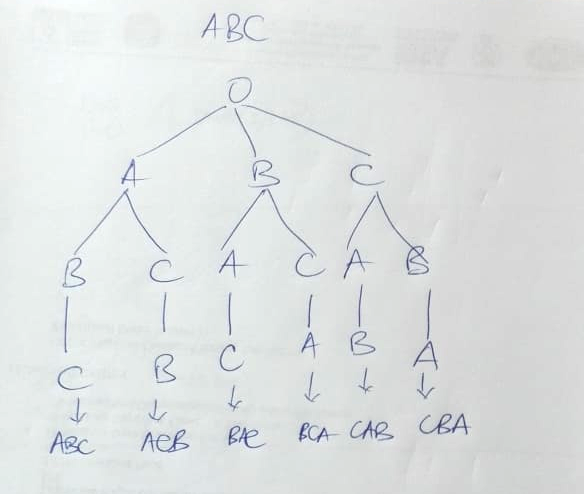

We use bruteforce to get all permutations.

Since we backtracking, we need to use recursion. And backtracking is normally implemented using recursion.

Lets write a recursive function.

We have the source array $S$. but we also need array from Results, lets call it $Res$. But we also need a flag array, lets call it $A$, to indicate which element/value is included or not.

This is $A$. $$ \newcommand\T{\Rule{0pt}{1em}{.3em}} \begin{array}{|r|r|r|r|r|r|r|r|r|r|} \hline 0\T&0\T&0\T&\text {\\}0 \\\hline _0\T&_1\T&_2\T&_3 \\\hline \end{array} $$

This is $Res$.

$$ \newcommand\T{\Rule{0pt}{1em}{.3em}} \begin{array}{|r|r|r|r|r|r|r|r|r|r|} \hline \T&\T&\T&\text {\\}0 \\\hline _0\T&_1\T&_2\T&_3 \\\hline \end{array} $$$$$$$$$$

**Lets start to trace:**

Here we going to use two variable counters, $i$ and $k$, for $A$ and $Res$.

$$ \text {RESULT - LEVEL 1}$$

Index position:

$k = 0$

$i = 0$

$$ \newcommand\T{\Rule{0pt}{1em}{.3em}} \begin{array}{|r|r|r|r|r|r|r|r|r|r|} \hline A\T&B\T&C\T&\text {\\}0 \\\hline _0\T&_1\T&_2\T&_3 \\\hline \end{array} $$$$ \newcommand\T{\Rule{0pt}{1em}{.3em}} \begin{array}{|r|r|r|r|r|r|r|r|r|r|} \hline 0\T&0\T&0\T&\text {\\}0 \\\hline _0\T&_1\T&_2\T&_3 \\\hline _i\T&\T&\T& \\\hline \end{array} $$$$ \newcommand\T{\Rule{0pt}{1em}{.3em}} \begin{array}{|r|r|r|r|r|r|r|r|r|r|} \hline \T&\T&\T&\text {\\}0 \\\hline _0\T&_1\T&_2\T&_3 \\\hline _k\T&\T&\T& \\\hline \end{array} $$

Is $i = 0$, No. Set it to 1. Check position $i$ in $S$. This is letter $A$. Set $k = A$ (this is letter $A$). Then call perm function (itself) again with values, k+1.

$$ \text {RESULT - LEVEL 2}$$

Index position:

$k = 1$

$i = 0$ (starts again from beginning)

$$ \newcommand\T{\Rule{0pt}{1em}{.3em}} \begin{array}{|r|r|r|r|r|r|r|r|r|r|} \hline A\T&B\T&C\T&\text {\\}0 \\\hline _0\T&_1\T&_2\T&_3 \\\hline \end{array} $$$$ \newcommand\T{\Rule{0pt}{1em}{.3em}} \begin{array}{|r|r|r|r|r|r|r|r|r|r|} \hline 1\T&0\T&0\T&\text {\\}0 \\\hline _0\T&_1\T&_2\T&_3 \\\hline _i\T&\T&\T& \\\hline \end{array} $$$$ \newcommand\T{\Rule{0pt}{1em}{.3em}} \begin{array}{|r|r|r|r|r|r|r|r|r|r|} \hline A\T&\T&\T&\text {\\}0 \\\hline _0\T&_1\T&_2\T&_3 \\\hline \T&_k\T&\T& \\\hline \end{array} $$

Is $i = 0$, No. Increment i.

$$ \text {RESULT - LEVEL 2}$$

Index position:

$k = 1$

$i = 1$

$$ \newcommand\T{\Rule{0pt}{1em}{.3em}} \begin{array}{|r|r|r|r|r|r|r|r|r|r|} \hline A\T&B\T&C\T&\text {\\}0 \\\hline _0\T&_1\T&_2\T&_3 \\\hline \end{array} $$$$ \newcommand\T{\Rule{0pt}{1em}{.3em}} \begin{array}{|r|r|r|r|r|r|r|r|r|r|} \hline 1\T&0\T&0\T&\text {\\}0 \\\hline _0\T&_1\T&_2\T&_3 \\\hline \T&_i\T&\T& \\\hline \end{array} $$$$ \newcommand\T{\Rule{0pt}{1em}{.3em}} \begin{array}{|r|r|r|r|r|r|r|r|r|r|} \hline A\T&\T&\T&\text {\\}0 \\\hline _0\T&_1\T&_2\T&_3 \\\hline \T&_k\T&\T& \\\hline \end{array} $$

Is $i = 0$, No. Set it to 1. Check position $i$ in $S$. This is letter $B$. Set $k = B$ (this is letter $B$). Then call perm function (itself) again with values, k+1.

$$ \text {RESULT - LEVEL 3}$$

$k = 2$

$i = 0$ (back to start at 0)

$$ \newcommand\T{\Rule{0pt}{1em}{.3em}} \begin{array}{|r|r|r|r|r|r|r|r|r|r|} \hline A\T&B\T&C\T&\text {\\}0 \\\hline _0\T&_1\T&_2\T&_3 \\\hline \end{array} $$$$ \newcommand\T{\Rule{0pt}{1em}{.3em}} \begin{array}{|r|r|r|r|r|r|r|r|r|r|} \hline 1\T&1\T&0\T&\text {\\}0 \\\hline _0\T&_1\T&_2\T&_3 \\\hline _i\T&\T&\T& \\\hline \end{array} $$$$ \newcommand\T{\Rule{0pt}{1em}{.3em}} \begin{array}{|r|r|r|r|r|r|r|r|r|r|} \hline A\T&B\T&\T&\text {\\}0 \\\hline _0\T&_1\T&_2\T&_3 \\\hline \T&\T&_k\T& \\\hline \end{array} $$

Is $i = 0$, No. Increment i.

$$ \text {RESULT - LEVEL 3}$$

Index position:

$k = 2$

$i = 1$

$$ \newcommand\T{\Rule{0pt}{1em}{.3em}} \begin{array}{|r|r|r|r|r|r|r|r|r|r|} \hline A\T&B\T&C\T&\text {\\}0 \\\hline _0\T&_1\T&_2\T&_3 \\\hline \end{array} $$$$ \newcommand\T{\Rule{0pt}{1em}{.3em}} \begin{array}{|r|r|r|r|r|r|r|r|r|r|} \hline 1\T&1\T&0\T&\text {\\}0 \\\hline _0\T&_1\T&_2\T&_3 \\\hline \T&_i\T&\T& \\\hline \end{array} $$$$ \newcommand\T{\Rule{0pt}{1em}{.3em}} \begin{array}{|r|r|r|r|r|r|r|r|r|r|} \hline A\T&B\T&\T&\text {\\}0 \\\hline _0\T&_1\T&_2\T&_3 \\\hline \T&_k\T&\T& \\\hline \end{array} $$

Is $i = 0$, No. Increment i.

$$ \text {RESULT - LEVEL 3}$$

Index position:

$k = 2$

$i = 2$

$$ \newcommand\T{\Rule{0pt}{1em}{.3em}} \begin{array}{|r|r|r|r|r|r|r|r|r|r|} \hline A\T&B\T&C\T&\text {\\}0 \\\hline _0\T&_1\T&_2\T&_3 \\\hline \end{array} $$$$ \newcommand\T{\Rule{0pt}{1em}{.3em}} \begin{array}{|r|r|r|r|r|r|r|r|r|r|} \hline 1\T&1\T&0\T&\text {\\}0 \\\hline _0\T&_1\T&_2\T&_3 \\\hline \T&\T&_i\T& \\\hline \end{array} $$$$ \newcommand\T{\Rule{0pt}{1em}{.3em}} \begin{array}{|r|r|r|r|r|r|r|r|r|r|} \hline A\T&B\T&\T&\text {\\}0 \\\hline _0\T&_1\T&_2\T&_3 \\\hline \T&\T&_k\T& \\\hline \end{array} $$

Is $i = 0$, No. Set it to 1. Check position $i$ in $S$. This is letter $C$. Set $k = C$ (this is letter $C$). Then call perm function (itself) again with values, k+1.

$$ \text {RESULT - LEVEL 3}$$

$k = 3$

$i = 2$

$$ \newcommand\T{\Rule{0pt}{1em}{.3em}} \begin{array}{|r|r|r|r|r|r|r|r|r|r|} \hline A\T&B\T&C\T&\text {\\}0 \\\hline _0\T&_1\T&_2\T&_3 \\\hline \end{array} $$$$ \newcommand\T{\Rule{0pt}{1em}{.3em}} \begin{array}{|r|r|r|r|r|r|r|r|r|r|} \hline 1\T&1\T&1\T&\text {\\}0 \\\hline _0\T&_1\T&_2\T&_3 \\\hline _i\T&\T&\T& \\\hline \end{array} $$$$ \newcommand\T{\Rule{0pt}{1em}{.3em}} \begin{array}{|r|r|r|r|r|r|r|r|r|r|} \hline A\T&B\T&C\T&\text {\\}0 \\\hline _0\T&_1\T&_2\T&_3 \\\hline \T&\T&\T&_k \\\hline \end{array} $$$$$$

Now we get to exit condition for perm.

Check if $k == \text{'\0'}$. Yes it is, print the permutation ($\text{ABC}$). Now we going to step back. What is value of $i$ and $k$, when we got to here:

Ignore $i$, as the exit condition only evaluates k.Also set the last char in Res= '\0':

```
if (S[k] =='\0'){
    cout<<"Permutation: "<<Res<<endl;
    Res[k]=='\0';
}
```

$$ \text {RESULT - LEVEL 3}$$

$k = 3$

$i = 1$

$$ \text {print: ABC}$$$$$$$$$$

$$$$$$$$$$\text {Fallback 1 position}$$$$$$

So where was $k$ and $i$ in the previous call: k = 2, i = 2.

$$ \text {RESULT - LEVEL 3}$$

Index position:

$k = 2$

$i = 2$ (make this zero ans scan again)

$$ \newcommand\T{\Rule{0pt}{1em}{.3em}} \begin{array}{|r|r|r|r|r|r|r|r|r|r|} \hline A\T&B\T&C\T&\text {\\}0 \\\hline _0\T&_1\T&_2\T&_3 \\\hline \end{array} $$$$ \newcommand\T{\Rule{0pt}{1em}{.3em}} \begin{array}{|r|r|r|r|r|r|r|r|r|r|} \hline 1\T&1\T&0\T&\text {\\}0 \\\hline _0\T&_1\T&_2\T&_3 \\\hline \T&\T&_i\T& \\\hline \end{array} $$$$ \newcommand\T{\Rule{0pt}{1em}{.3em}} \begin{array}{|r|r|r|r|r|r|r|r|r|r|} \hline A\T&B\T&C\T&\text {\\}0 \\\hline _0\T&_1\T&_2\T&_3 \\\hline \T&\T&_k\T& \\\hline \end{array} $$$$$$$$ \text {RESULT - LEVEL 3}$$

Increment i. But now we reached $A[i]==\text{'\0'}$.

$k = 2$

$i = 3$

$$ \newcommand\T{\Rule{0pt}{1em}{.3em}} \begin{array}{|r|r|r|r|r|r|r|r|r|r|} \hline A\T&B\T&C\T&\text {\\}0 \\\hline _0\T&_1\T&_2\T&_3 \\\hline \end{array} $$$$ \newcommand\T{\Rule{0pt}{1em}{.3em}} \begin{array}{|r|r|r|r|r|r|r|r|r|r|} \hline 1\T&1\T&0\T&\text {\\}0 \\\hline _0\T&_1\T&_2\T&_3 \\\hline \T&\T&\T&_i \\\hline \end{array} $$$$ \newcommand\T{\Rule{0pt}{1em}{.3em}} \begin{array}{|r|r|r|r|r|r|r|r|r|r|} \hline A\T&B\T&C\T&\text {\\}0 \\\hline _0\T&_1\T&_2\T&_3 \\\hline \T&\T&_k\T& \\\hline \end{array} $$$$ \text {RESULT - LEVEL 2}$$$$\text {Fallback 1 position}$$

So where was $k$ and $i$ in this call: k = 1, i = 1.

$$$$

$k = 1$

$i = 1$

$$ \newcommand\T{\Rule{0pt}{1em}{.3em}} \begin{array}{|r|r|r|r|r|r|r|r|r|r|} \hline A\T&B\T&C\T&\text {\\}0 \\\hline _0\T&_1\T&_2\T&_3 \\\hline \end{array} $$$$ \newcommand\T{\Rule{0pt}{1em}{.3em}} \begin{array}{|r|r|r|r|r|r|r|r|r|r|} \hline 1\T&0\T&0\T&\text {\\}0 \\\hline _0\T&_1\T&_2\T&_3 \\\hline \T&_i\T&\T& \\\hline \end{array} $$$$ \newcommand\T{\Rule{0pt}{1em}{.3em}} \begin{array}{|r|r|r|r|r|r|r|r|r|r|} \hline A\T&B\T&C\T&\text {\\}0 \\\hline _0\T&_1\T&_2\T&_3 \\\hline \T&_k\T&\T& \\\hline \end{array} $$

Increment i.Is $i = 0$, Yes. Set it to 1. Check position $i$ in $S$. This is letter $C$. Set $k = C$ (this is letter $C$). Then call perm function (itself) again with values, k+1.

$$ \text {RESULT - LEVEL 3}$$

$k = 2$

$i = 0$ (back to start at 0)

$$ \newcommand\T{\Rule{0pt}{1em}{.3em}} \begin{array}{|r|r|r|r|r|r|r|r|r|r|} \hline A\T&B\T&C\T&\text {\\}0 \\\hline _0\T&_1\T&_2\T&_3 \\\hline \end{array} $$$$ \newcommand\T{\Rule{0pt}{1em}{.3em}} \begin{array}{|r|r|r|r|r|r|r|r|r|r|} \hline 1\T&0\T&1\T&\text {\\}0 \\\hline _0\T&_1\T&_2\T&_3 \\\hline _i\T&\T&\T& \\\hline \end{array} $$$$ \newcommand\T{\Rule{0pt}{1em}{.3em}} \begin{array}{|r|r|r|r|r|r|r|r|r|r|} \hline A\T&C\T&C\T&\text {\\}0 \\\hline _0\T&_1\T&_2\T&_3 \\\hline \T&\T&_k\T& \\\hline \end{array} $$$$$$

$$ \text {RESULT - LEVEL 3}$$

Index position:

$k = 2$

$i = 1$

$$ \newcommand\T{\Rule{0pt}{1em}{.3em}} \begin{array}{|r|r|r|r|r|r|r|r|r|r|} \hline A\T&B\T&C\T&\text {\\}0 \\\hline _0\T&_1\T&_2\T&_3 \\\hline \end{array} $$$$ \newcommand\T{\Rule{0pt}{1em}{.3em}} \begin{array}{|r|r|r|r|r|r|r|r|r|r|} \hline 1\T&0\T&1\T&\text {\\}0 \\\hline _0\T&_1\T&_2\T&_3 \\\hline \T&_i\T&\T& \\\hline \end{array} $$$$ \newcommand\T{\Rule{0pt}{1em}{.3em}} \begin{array}{|r|r|r|r|r|r|r|r|r|r|} \hline A\T&C\T&C\T&\text {\\}0 \\\hline _0\T&_1\T&_2\T&_3 \\\hline \T&\T&_k\T& \\\hline \end{array} $$

$$ \text {RESULT - LEVEL 3}$$

Index position:

$k = 3$

$i = 2$

$$ \newcommand\T{\Rule{0pt}{1em}{.3em}} \begin{array}{|r|r|r|r|r|r|r|r|r|r|} \hline A\T&B\T&C\T&\text {\\}0 \\\hline _0\T&_1\T&_2\T&_3 \\\hline \end{array} $$$$ \newcommand\T{\Rule{0pt}{1em}{.3em}} \begin{array}{|r|r|r|r|r|r|r|r|r|r|} \hline 1\T&1\T&1\T&\text {\\}0 \\\hline _0\T&_1\T&_2\T&_3 \\\hline \T&\T&_i\T& \\\hline \end{array} $$$$ \newcommand\T{\Rule{0pt}{1em}{.3em}} \begin{array}{|r|r|r|r|r|r|r|r|r|r|} \hline A\T&C\T&B\T&\text {\\}0 \\\hline _0\T&_1\T&_2\T&_3 \\\hline \T&\T&\T&_k \\\hline \end{array} $$$$$$

Now we get to exit condition for perm.

Check if $k == \text{'\0'}$. Yes it is, print the permutation ($\text{ACB}$). Now we going to step back. What is value of $i$ and $k$, when we got to here:

$k = 2$

$i = 1$ (make this zero ans scan again)

$$ \text {print: ACB}$$$$$$$$$$

$$$$$$$$

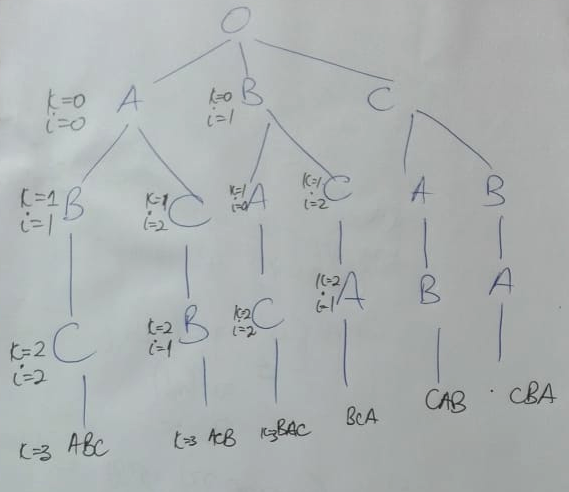

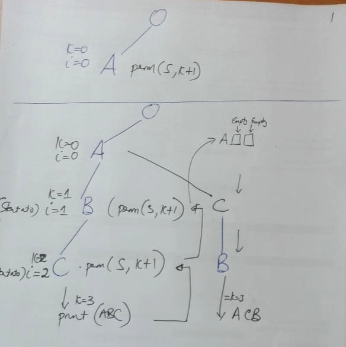

Rinse and REPEAT.

Some points:

1. When you reach end of i, you step 1 position back, and set that position equal to zero.
2. Increment i, to get next position.
3. Once you print, find previous value, that is step back, set position = 0, and repeat, go forward like normal.

## Second method to find permutation

Lets call this $S$:

$$ \newcommand\T{\Rule{0pt}{1em}{.3em}} \begin{array}{|r|r|r|r|r|r|r|r|r|r|} \hline A\T&B\T&C\T&\text {\\}0 \\\hline _0\T&_1\T&_2\T&_3 \\\hline \end{array} $$

Here we will be using swapping. And so we need two variables, $l$, for low index and $h$, for high index. And use $i$ as counter.

$$ \newcommand\T{\Rule{0pt}{1em}{.3em}} \begin{array}{|r|r|r|r|r|r|r|r|r|r|} \hline _l\T&\T&h\T& \\\hline A\T&B\T&C\T&\text {\\}0 \\\hline _0\T&_1\T&_2\T&_3 \\\hline _i\T&\T&\T& \\\hline \end{array} $$$$$$$$$$

We swap $i$ and $l$. A becomes A. Increment $i$ and $l$.

$$ \text {RESULT}$$

$i = 1$

$l = 1$

$h = 2$

$$ \newcommand\T{\Rule{0pt}{1em}{.3em}} \begin{array}{|r|r|r|r|r|r|r|r|r|r|} \hline \T&_l\T&h\T& \\\hline A\T&B\T&C\T&\text {\\}0 \\\hline _0\T&_1\T&_2\T&_3 \\\hline \T&_i\T&\T& \\\hline \end{array} $$$$$$

We swap $i$ and $l$. B becomes B. Increment $i$ and $l$

$$ \text {RESULT}$$

$i = 2$

$l = 2$

$h = 2$

$$ \newcommand\T{\Rule{0pt}{1em}{.3em}} \begin{array}{|r|r|r|r|r|r|r|r|r|r|} \hline \T&\T&h+l\T& \\\hline A\T&B\T&C\T&\text {\\}0 \\\hline _0\T&_1\T&_2\T&_3 \\\hline \T&\T&_i\T& \\\hline \end{array} $$$$$$

l = h. Print result, ABC

$$ \text {RESULT}$$$$\text{ABC}$$

Go back to previous call:

$i = 1$

$l = 1$

$h = 2$

$$ \newcommand\T{\Rule{0pt}{1em}{.3em}} \begin{array}{|r|r|r|r|r|r|r|r|r|r|} \hline \T&_l\T&h\T& \\\hline A\T&B\T&C\T&\text {\\}0 \\\hline _0\T&_1\T&_2\T&_3 \\\hline \T&_i\T&\T& \\\hline \end{array} $$

Increment i (set to 2). Keep $l$ at $1$.

$$ \newcommand\T{\Rule{0pt}{1em}{.3em}} \begin{array}{|r|r|r|r|r|r|r|r|r|r|} \hline \T&_l\T&h\T& \\\hline A\T&B\T&C\T&\text {\\}0 \\\hline _0\T&_1\T&_2\T&_3 \\\hline \T&\T&_i\T& \\\hline \end{array} $$

We swap $i(C)$ and $l(B)$. C becomes B.

Increment $i$ and $l$

$$ \newcommand\T{\Rule{0pt}{1em}{.3em}} \begin{array}{|r|r|r|r|r|r|r|r|r|r|} \hline \T&\T&h+l\T& \\\hline A\T&C\T&B\T&\text {\\}0 \\\hline _0\T&_1\T&_2\T&_3 \\\hline \T&\T&\T& \\\hline \end{array} $$

($i$ is outside range)

$$$$

l = h. Print result, ACB

$$ \text {RESULT}$$$$\text{ACB}$$

Swap i and l back to original places.

$$ \newcommand\T{\Rule{0pt}{1em}{.3em}} \begin{array}{|r|r|r|r|r|r|r|r|r|r|} \hline \T&l\T&h\T& \\\hline A\T&B\T&C\T&\text {\\}0 \\\hline _0\T&_1\T&_2\T&_3 \\\hline \T&\T&_i\T& \\\hline \end{array} $$

Go back to previous call:

$i = 0$

$l = 0$

$h = 2$

$$ \newcommand\T{\Rule{0pt}{1em}{.3em}} \begin{array}{|r|r|r|r|r|r|r|r|r|r|} \hline _l\T&\T&h\T& \\\hline A\T&B\T&C\T&\text {\\}0 \\\hline _0\T&_1\T&_2\T&_3 \\\hline _i\T&\T&\T& \\\hline \end{array} $$

$$ \newcommand\T{\Rule{0pt}{1em}{.3em}} \begin{array}{|r|r|r|r|r|r|r|r|r|r|} \hline _l\T&\T&h\T& \\\hline A\T&B\T&C\T&\text {\\}0 \\\hline _0\T&_1\T&_2\T&_3 \\\hline \T&_1\T&\T& \\\hline \end{array} $$

We swap $i(B)$ and $l(A)$. A becomes B.

Increment $i$ and $l$

$$ \newcommand\T{\Rule{0pt}{1em}{.3em}} \begin{array}{|r|r|r|r|r|r|r|r|r|r|} \hline \T&l\T&h\T& \\\hline B\T&A\T&C\T&\text {\\}0 \\\hline _0\T&_1\T&_2\T&_3 \\\hline \T&\T&_i\T& \\\hline \end{array} $$

etc. etc. etc.

```python
#include <iostream>
#include <climits>
#include <math.h>
using namespace std;
```

```python
void perm (char S[], int k){

static int  A[3]={0};
static char Res[3];
int i;

    if (S[k] =='\0'){
        cout<<"Permutation: "<<Res<<endl;
        Res[k]='\0';
    }
    else
    {
        for(int i = 0; S[i]!='\0';i++){
            if (A[i]==0){
                Res[k]=S[i];
                A[i]=1;
                perm(S,k+1);
                A[i]=0;
            }
        }
    }
}
```

```python
char  S[]="ABC";
perm(S,0);
```

```
Permutation: ABC
Permutation: ACB
Permutation: BAC
Permutation: BCA
Permutation: CAB
Permutation: CBA
```

## Method Two

```python
void swap(char *x, char *y){
    char temp;
    temp = *x;
    *x = *y;
    *y = temp;

}
```

```python
void perms (char S[], int l, int h){

int i = 0;
    if (l == h)
      cout<<"Permutation: " <<S<<endl;
    else{
        for(i = l; i <= h;i++){
            swap(&S[l], &S[i]);
            perms(S,l+1, h);
            swap(&S[l], &S[i]);
        }
    }
}
```

```python
char  SS[]="ABC";
perms(SS,0,2);
```

```
Permutation: ABC
Permutation: ACB
Permutation: BAC
Permutation: BCA
Permutation: CBA
Permutation: CAB
```